# Projekt Viridian

## Wirtschaft ist Lebensgrundlage…

[figure not shown]

[Foto von Renate Vanaga auf Unsplash (Ausschnitt)](https://unsplash.com/photos/2pV2LwPVP9A)

## …aber verursacht auch viele Probleme Überschreitung der planetaren Grenzen

[figure not shown]

"Beyond the boundary", Fig. 1 aus dem Nature-Artikel ["A safe operating space for humanity"](https://www.nature.com/articles/461472a) (Rockström et al. 2009)

## …aber verursacht auch viele Probleme Zerstörung/Verschmutzung

[figure not shown]

[Grasberg-Mine, Alfindra Primaldhi (2007), CC BY 2.0](https://en.wikipedia.org/wiki/File:Grasberg_mine.jpg)

[figure not shown]

[Tagebau Hambach, vom Aussichtspunkt Elsdorf-Angelsdorf gesehen, Johannes Fasolt (2006), gemeinfrei](https://commons.wikimedia.org/wiki/File:Surface_Mining_Hambach_200800806.jpg)

## …aber verursacht auch viele Probleme Zerstörung/Verschmutzung

Vorher:

[figure not shown]

Pristine Canadian boreal forest photographed by […] Garth Lenz, [Cool Davis](https://www.cooldavis.org/2012/12/19/the-true-cost-of-oil-images-of-beauty-and-devastation/), [CC BY-NC 3.0](https://creativecommons.org/licenses/by-nc/3.0/)

Nachher:

[figure not shown]

Ölsandabbau: Tar sands mining region in the Canadian boreal forest photographed by Garth Lenz, [Cool Davis](https://www.cooldavis.org/2012/12/19/the-true-cost-of-oil-images-of-beauty-and-devastation/), [CC BY-NC 3.0](https://creativecommons.org/licenses/by-nc/3.0/)

## …aber verursacht auch viele Probleme Klimakrise

[figure not shown]

Von [Cayobo](https://www.flickr.com/people/58003213@N00) from Key West, The Conch Republic - [Hurricane Dorian Eye](https://www.flickr.com/photos/cayobo/48667030183/), [CC BY 2.0](https://creativecommons.org/licenses/by/2.0), [Link](https://commons.wikimedia.org/w/index.php?curid=81889943)

## …aber verursacht auch viele Probleme Klimakrise

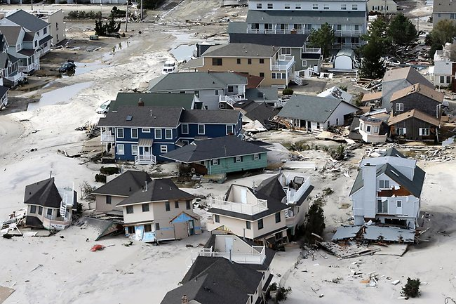

["Superstorm Sandy"](https://amazonsday.blogspot.com/2015/03/blog-post_16.html), von sonora, [CC BY-NC-ND 3.0](https://creativecommons.org/licenses/by-nc-nd/3.0/deed.en)

## …aber verursacht auch viele Probleme Klimakrise (auch hier bei uns!)

[figure not shown]

[Deutschland auf Platz 3](https://germanwatch.org/de/17330) im [Klima-Risiko-Index (KRI)](https://germanwatch.org/de/kri) von Germanwatch e.V.

## …aber verursacht auch viele Probleme Klimakrise

> "Climate models project increased aridity in the 21<sup>st</sup> century over most of Africa, southern Europe and the Middle East […]" Aiguo Dai (2010): "Drought under Global Warming"

[figure not shown]

## …aber verursacht auch viele Probleme Miserable Arbeitsbedingungen

[figure not shown]

Von [rijans](https://www.flickr.com/people/40831205@N02) - Flickr: [Dhaka Savar Building Collapse](https://www.flickr.com/photos/40831205@N02/8731789941), [CC BY-SA 2.0](https://creativecommons.org/licenses/by-sa/2.0), [Link](https://commons.wikimedia.org/w/index.php?curid=26051590)

## …aber verursacht auch viele Probleme Miserable Arbeitsbedingungen

[figure not shown]

["PER NON DIMENTICARE"](http://www.scuolesenzapermesso.org/a-un-anno-dalla-tragedia-di-rana-plaza-in-cui-perirono-1127-persone-per-non-dimenticare/) ("Um nicht zu vergessen – Ein Jahr nach der Tragödie von Rana Plaza"), von scuolabinari, modifiziert, [CC BY-NC 3.0](https://creativecommons.org/licenses/by-nc/3.0/deed.en_US)

## …aber verursacht auch viele Probleme Tierhaltung: Nitratbelastung und multiresistente Keime

[figure not shown]

Bild von [Myriam Zilles](https://pixabay.com/de/users/Myriams-Fotos-1627417/?utm_source=link-attribution&utm_medium=referral&utm_campaign=image&utm_content=1302596) auf [Pixabay](https://pixabay.com/de/?utm_source=link-attribution&utm_medium=referral&utm_campaign=image&utm_content=1302596)

## Warum passiert das?

[figure not shown]

Photo by [Robert Anasch](https://unsplash.com/@diesektion?utm_source=unsplash&utm_medium=referral&utm_content=creditCopyText) on [Unsplash](https://unsplash.com/@diesektion?utm_source=unsplash&utm_medium=referral&utm_content=creditCopyText)

## Gerechtigkeit

…wäre, wenn das ["Verursacherprinzip"](https://de.wikipedia.org/wiki/Verursacherprinzip) gelten würde. Wer Schäden verursacht, muss für die Konsequenzen aufkommen. Das würde helfen, Schäden von vornherein zu vermeiden.

[figure not shown]

[Justitia](https://www.flickr.com/photos/foto_db/19138839664), von [Tim Reckmann](https://www.flickr.com/photos/foto_db/), [CC BY 2.0](https://creativecommons.org/licenses/by/2.0/)

\(\rightarrow\) Externalisierte Kosten einpreisen!

## Politik könnte eingreifen, aber…

[figure not shown]

[Jacob Jung Blog](https://jacobjung.wordpress.com/2011/05/22/hilfe-mutti-dreht-durch-ich-glaub-ich-schreib-der-merkel-mal-was-auf/), [CC BY-NC 3.0](https://creativecommons.org/licenses/by-nc/3.0/deed.de)

[figure not shown]

[A Quiet Walk](https://aquietwalk.com/2017/03/13/a-small-sad-little-man/), [CC BY 3.0 US](https://creativecommons.org/licenses/by/3.0/us/)

[figure not shown]

Based on User:Mark Miller, User:Herostratus and User:Masur [Public domain], [via Wikimedia Commons](https://commons.wikimedia.org/wiki/File:A_no_money_handshake.svg)

**Möglichkeiten:** Besteuerung, Grenzwerte für Verschmutzung, Verbote, Zertifikatehandel, …

Es passiert aber nichts… oder es dauert zu lange.

## Was können **wir** tun?

Wir Verbraucher sind ein "schlafender Riese"

[figure not shown]

Av [Theodor Kittelsen](https://en.wikipedia.org/wiki/nn:Theodor_Kittelsen) – http://www2.skolenettet.no/kunstweb/bilde/galleri/kittelsen.html, Offentlig eiendom, [Lenke](https://commons.wikimedia.org/w/index.php?curid=122555)

## Die Transparenzplattform: "Viridian"

[figure not shown]

- Ein **"Commons"** wie Wikipedia
- **Unabhängig** von politischen oder ökonomischen Interessen
- Wird von keinem kontrolliert
- Jede*r kann Informationen einsehen
- Jede*r kann beitragen und bearbeiten
- Über **Blockchain** dezentral organisiert und vor Manipulation geschützt
- Über **Peer-Review** und Reputationssystem vor unsachlichen Inhalten und Beeinflussung geschützt
- **Schutz** vor Sybil-Attacken durch Identitätscheck ("Permissioned Blockchain")

## Die Transparenzplattform: "Viridian"

[figure not shown]

- **Bündelung** sämtlicher Informationen: Berechnung ext. Kosten, LCA, CSR, NGO-Studien, Investigativ-Berichte, Gerichtsurteile, Siegel, Whistleblower, …
- **Teilnahme auf mehreren Ebenen:**
  - **Hoher Aufwand:** Information (mit Quellen) hinzufügen
  - **Mittlerer Aufwand:** Eine Information bewerten/interpretieren
  - **Geringer Aufwand:** Eine Bewertung upvoten/downvoten (zustimmen/ablehnen) und dadurch gewichten
  - **Kein Aufwand:** Nur Ergebnisse ansehen
- *Wer nur wenig Zeit hat, kann trotzdem partizipieren*

## Die Transparenzplattform: "Viridian"

- **Informationen auf mehreren Ebenen:**
  - Produkt
  - Produktkategorie
  - Siegel
  - Unternehmen
- Informationen werden **"vererbt"**
- *Wenn nur wenig bekannt ist, kann trotzdem im Groben begonnen werden*
- Dann immer weiter verfeinern und mit spezifischen Informationen anreichern!

## Schlussbemerkung

- Schaffung der "Stiftung Warentest" durch einen Bundestagsbeschluss im Dezember 1964:

> "[…] zweitbeste Lösung […]"
- Zeit für die "beste Lösung": Eine von der Zivilgesellschaft ausgehende, demokratische Verbraucherinformationsplattform

https://www.viridian-project.org

[figure not shown]